# tidymodel walkthrough

Yifei Liu

8/3/2020

[tidymodel](https://www.tidymodels.org/start/models/)

# 1. Build a model

## Introduction

```r
library(tidyverse)
library(tidymodels) # for the parsnip package, along with the rest tidymodels
# helper packages
library(readr) # for importing data
library(broom.mixed)
theme_set(theme_minimal())
```

## The sea urchins data

```r
urchins <-
  # Data were assembled for a tutorial
  # at https://www.flutterbys.com.au/stats/tut/tut7.5a.html
  read_csv("https://tidymodels.org/start/models/urchins.csv") %>%
  # Change the names to be a little more verbose
  setNames(c("food_regime", "initial_volume", "width")) %>%
  # Factors are very helpful for modeling, so we convert one column
  mutate(food_regime = factor(food_regime, levels = c("Initial", "Low", "High")))
urchins %>%
  count(food_regime)
```

```
## # A tibble: 3 x 2
##   food_regime     n
##   <fct>       <int>
## 1 Initial        24
## 2 Low            24
## 3 High           24
```

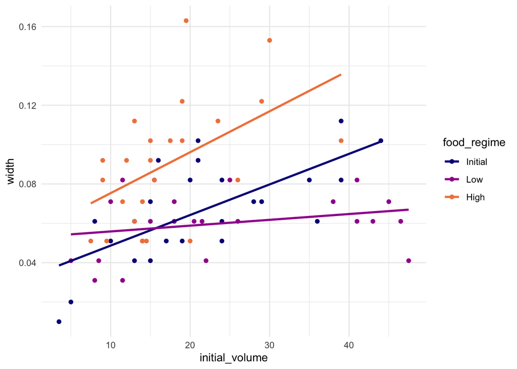

```r
ggplot(urchins, aes(initial_volume, width,
                    group = food_regime, col = food_regime)) +
  geom_point() +
  geom_smooth(method = "lm", se = F) +
  scale_color_viridis_d(option = "plasma", end = .7)
```

## Build and fit a model

now that the type of model has been specified, a method for fitting or training the model can be stated using engine. The engine value is often a mash-up of the software that can be used to fit or train the model as well as the estimation method. For example, to use ordinary least squares. we can set the engine to *lm*

```r
lm_mod <-
  linear_reg() %>%
  set_engine("lm")
```

from here, the model can be estiamted or trained using the *fit()* function

```r
lm_fit <-
  lm_mod %>%
  fit(width ~ initial_volume * food_regime, data = urchins)

lm_fit
```

```
## parsnip model object
##
## Fit time:  5ms
##
## Call:
## stats::lm(formula = width ~ initial_volume * food_regime, data = data)
##
## Coefficients:
##                    (Intercept)                  initial_volume
##                      0.0331216                       0.0015546
##                 food_regimeLow                 food_regimeHigh
##                      0.0197824                       0.0214111
##  initial_volume:food_regimeLow  initial_volume:food_regimeHigh
##                     -0.0012594                       0.0005254
```

Perhaps our analysis requires a description of the model parameter estimates and their statisitcal properities. Although the summary function for lm method can provide that, it gives the results back in an unwieldy format. Many models have tidy method that provides the summary result in a more predictable and useful format. (a DataFrame with standard column names)

```r
tidy(lm_fit)
```

```
## # A tibble: 6 x 5
##   term                            estimate std.error statistic  p.value
##   <chr>                              <dbl>     <dbl>     <dbl>    <dbl>
## 1 (Intercept)                     0.0331    0.00962      3.44  0.00100
## 2 initial_volume                  0.00155   0.000398     3.91  0.000222
## 3 food_regimeLow                  0.0198    0.0130       1.52  0.133
## 4 food_regimeHigh                 0.0214    0.0145       1.47  0.145
## 5 initial_volume:food_regimeLow  -0.00126   0.000510    -2.47  0.0162
## 6 initial_volume:food_regimeHigh  0.000525  0.000702     0.748 0.457
```

## Use a model to predict

```r
new_points <- expand_grid(initial_volume = 20,
                          food_regime = c("Initial", "Low", "High"))

new_points
```

```
## # A tibble: 3 x 2
##   initial_volume food_regime
##            <dbl> <chr>
## 1             20 Initial
## 2             20 Low
## 3             20 High
```

tidymodel function standardized the syntax around different predicting model

```r
mean_pred <- predict(lm_fit, new_data = new_points)


mean_pred
```

```
## # A tibble: 3 x 1
##    .pred
##    <dbl>
## 1 0.0642
## 2 0.0588
## 3 0.0961
```

```r
conf_int_pred <- predict(lm_fit,
                         new_data = new_points,
                         type = "conf_int")

conf_int_pred
```

```
## # A tibble: 3 x 2
##   .pred_lower .pred_upper
##         <dbl>       <dbl>
## 1      0.0555      0.0729
## 2      0.0499      0.0678
## 3      0.0870      0.105
```

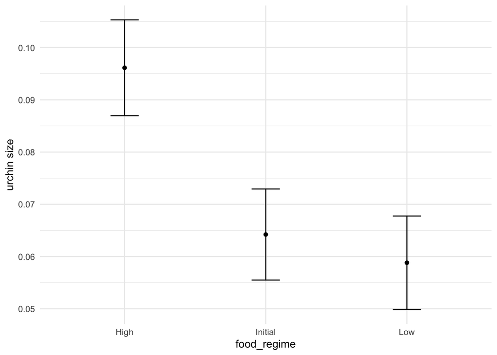

```r
# now combine the interval and predicted values

plot_data <-
  new_points %>%
  bind_cols(mean_pred) %>%
  bind_cols(conf_int_pred)

# and plot

ggplot(plot_data, aes(food_regime)) +
  geom_point(aes(y = .pred)) +
  geom_errorbar(aes(ymin = .pred_lower,
                    ymax = .pred_upper,
                    width = .2)) +
  labs(y = "urchin size")
```

## Model with a different engine

```r
# set the prior distribution

prior_dist <- rstanarm::student_t(df = 1)
# set seed
set.seed(123)

# make the parsnip model

bayes_mod <-
  linear_reg() %>%
  set_engine("stan",
             prior_intercept = prior_dist,
             prior = prior_dist)
# train the model

bayes_fit <-
  bayes_mod %>%
  fit(width ~ initial_volume * food_regime, data = urchins)


print(bayes_fit, digits = 5)
```

```
## parsnip model object
##
## Fit time:  1.8s
## stan_glm
##  family:       gaussian [identity]
##  formula:      width ~ initial_volume * food_regime
##  observations: 72
##  predictors:   6
## ------
##                                Median   MAD_SD
## (Intercept)                     0.03452  0.00883
## initial_volume                  0.00150  0.00037
## food_regimeLow                  0.01805  0.01221
## food_regimeHigh                 0.01934  0.01367
## initial_volume:food_regimeLow  -0.00119  0.00047
## initial_volume:food_regimeHigh  0.00061  0.00065
##
## Auxiliary parameter(s):
##       Median  MAD_SD
## sigma 0.02121 0.00186
##
## ------
## * For help interpreting the printed output see ?print.stanreg
## * For info on the priors used see ?prior_summary.stanreg
```

```r
tidy(bayes_fit, conf.int = TRUE)
```

```
## # A tibble: 6 x 5
##   term                            estimate std.error  conf.low conf.high
##   <chr>                              <dbl>     <dbl>     <dbl>     <dbl>
## 1 (Intercept)                     0.0345    0.00883   0.0200    0.0490
## 2 initial_volume                  0.00150   0.000369  0.000895  0.00212
## 3 food_regimeLow                  0.0181    0.0122   -0.00181   0.0380
## 4 food_regimeHigh                 0.0193    0.0137   -0.00317   0.0420
## 5 initial_volume:food_regimeLow  -0.00119   0.000472 -0.00199  -0.000413
## 6 initial_volume:food_regimeHigh  0.000610  0.000651 -0.000490  0.00170
```

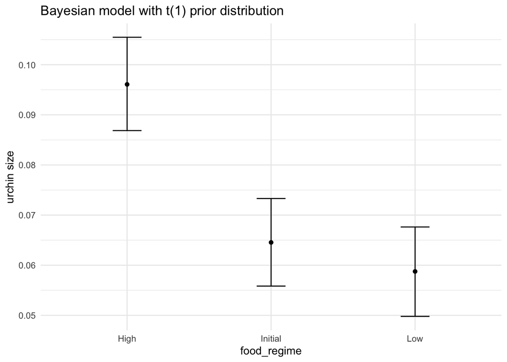

```r
bayes_plot_data <-
  new_points %>%
  bind_cols(predict(bayes_fit, new_data = new_points)) %>%
  bind_cols(predict(bayes_fit, new_data = new_points, type = "conf_int"))


ggplot(bayes_plot_data, aes(x = food_regime)) +
  geom_point(aes(y = .pred)) +
  geom_errorbar(aes(ymin = .pred_lower, ymax = .pred_upper), width = .2) +
  labs(y = "urchin size",
       title = "Bayesian model with t(1) prior distribution")
```

## Why does it work that way?

standard modeling function is that they don’t separate what you want from the execution. For example, the process of executing a formula has not happen repeatedly across model calls even when the formula does not change. We can’t recycle those computation

```r
urchins %>%
  group_by(food_regime) %>%
  summarize(med_vol = median(initial_volume))
```

```
## # A tibble: 3 x 2
##   food_regime med_vol
##   <fct>         <dbl>
## 1 Initial        20.5
## 2 Low            19.2
## 3 High           15
```

```r
bayes_mod %>%
  fit(width ~ initial_volume * food_regime, data = urchins)
```

```
## parsnip model object
##
## Fit time:  2s
## stan_glm
##  family:       gaussian [identity]
##  formula:      width ~ initial_volume * food_regime
##  observations: 72
##  predictors:   6
## ------
##                                Median MAD_SD
## (Intercept)                    0.0    0.0
## initial_volume                 0.0    0.0
## food_regimeLow                 0.0    0.0
## food_regimeHigh                0.0    0.0
## initial_volume:food_regimeLow  0.0    0.0
## initial_volume:food_regimeHigh 0.0    0.0
##
## Auxiliary parameter(s):
##       Median MAD_SD
## sigma 0.0    0.0
##
## ------
## * For help interpreting the printed output see ?print.stanreg
## * For info on the priors used see ?prior_summary.stanreg
```

# Preprocess your data with recipes

```r
library(nycflights13)
library(skimr)
```

## The New york city flight data

```r
flights_data <-
  flights %>%
  mutate(
    arr_delay = ifelse(arr_delay >= 30, "late", "on_time"),
    arr_delay = factor(arr_delay),
    date = as.Date(time_hour)
    ) %>%
  inner_join(weather, by = c("origin", "time_hour")) %>%
  select(dep_time, flight, origin, dest, air_time, distance,
         carrier, date, arr_delay, time_hour) %>%
  na.omit() %>%
  mutate_if(is.character, as.factor)
```

```r
flights_data %>%
  count(arr_delay) %>%
  mutate(prop = n / sum(n))
```

```
## # A tibble: 2 x 3
##   arr_delay      n  prop
##   <fct>      <int> <dbl>
## 1 late       52540 0.161
## 2 on_time   273279 0.839
```

```r
glimpse(flights_data)
```

```
## Rows: 325,819
## Columns: 10
## $ dep_time  <int> 517, 533, 542, 544, 554, 554, 555, 557, 557, 558, 558, 558,…
## $ flight    <int> 1545, 1714, 1141, 725, 461, 1696, 507, 5708, 79, 301, 49, 7…
## $ origin    <fct> EWR, LGA, JFK, JFK, LGA, EWR, EWR, LGA, JFK, LGA, JFK, JFK,…
## $ dest      <fct> IAH, IAH, MIA, BQN, ATL, ORD, FLL, IAD, MCO, ORD, PBI, TPA,…
## $ air_time  <dbl> 227, 227, 160, 183, 116, 150, 158, 53, 140, 138, 149, 158, …
## $ distance  <dbl> 1400, 1416, 1089, 1576, 762, 719, 1065, 229, 944, 733, 1028…
## $ carrier   <fct> UA, UA, AA, B6, DL, UA, B6, EV, B6, AA, B6, B6, UA, UA, AA,…
## $ date      <date> 2013-01-01, 2013-01-01, 2013-01-01, 2013-01-01, 2013-01-01…
## $ arr_delay <fct> on_time, on_time, late, on_time, on_time, on_time, on_time,…
## $ time_hour <dttm> 2013-01-01 05:00:00, 2013-01-01 05:00:00, 2013-01-01 05:00…
```

```r
flights_data %>%
  skimr::skim(dest, carrier)
```

Data summary

| Name | Piped data |
| --- | --- |
| Number of rows | 325819 |
| Number of columns | 10 |
| _______________________ |  |
| Column type frequency: |  |
| factor | 2 |
| ________________________ |  |
| Group variables | None |

**Variable type: factor**

| skim_variable | n_missing | complete_rate | ordered | n_unique | top_counts |
| --- | --- | --- | --- | --- | --- |
| dest | 0 | 1 | FALSE | 104 | ATL: 16771, ORD: 16507, LAX: 15942, BOS: 14948 |
| carrier | 0 | 1 | FALSE | 16 | UA: 57489, B6: 53715, EV: 50868, DL: 47465 |

## Data Splitting

```r
set.seed(555)

data_split <- initial_split(flights_data, prop = 3/4)

train_data <- training(data_split)
test_data <- testing(data_split)
```

## Create recipe and roles

```r
flights_rec <-
  recipe(arr_delay ~ ., data = train_data)
```

```r
flights_rec <-
  recipe(arr_delay ~ ., data = train_data) %>%
  update_role(flight, time_hour, new_role = "ID")

summary(flights_rec)
```

```
## # A tibble: 10 x 4
##    variable  type    role      source
##    <chr>     <chr>   <chr>     <chr>
##  1 dep_time  numeric predictor original
##  2 flight    numeric ID        original
##  3 origin    nominal predictor original
##  4 dest      nominal predictor original
##  5 air_time  numeric predictor original
##  6 distance  numeric predictor original
##  7 carrier   nominal predictor original
##  8 date      date    predictor original
##  9 time_hour date    ID        original
## 10 arr_delay nominal outcome   original
```

## Create features

```r
flights_data %>%
  distinct(date) %>%
  mutate(numeric_date = as.numeric(date))
```

```
## # A tibble: 364 x 2
##    date       numeric_date
##    <date>            <dbl>
##  1 2013-01-01        15706
##  2 2013-01-02        15707
##  3 2013-01-03        15708
##  4 2013-01-04        15709
##  5 2013-01-05        15710
##  6 2013-01-06        15711
##  7 2013-01-07        15712
##  8 2013-01-08        15713
##  9 2013-01-09        15714
## 10 2013-01-10        15715
## # … with 354 more rows
```

it’s possible that the numeric date vaiable is a good option for modeling; perhaps the model would benefit from a linear trend between the log-odds for a late arrival and the numeric date variable,

```r
flights_rec <-
  recipe(arr_delay ~ ., data = train_data) %>%
  update_role(flight, time_hour, new_role = "ID") %>%
  step_date(date, features = c("dow", "month")) %>%
  step_holiday(date, holidays = timeDate::listHolidays("US")) %>%
  step_rm(date)

summary(flights_rec)
```

```
## # A tibble: 10 x 4
##    variable  type    role      source
##    <chr>     <chr>   <chr>     <chr>
##  1 dep_time  numeric predictor original
##  2 flight    numeric ID        original
##  3 origin    nominal predictor original
##  4 dest      nominal predictor original
##  5 air_time  numeric predictor original
##  6 distance  numeric predictor original
##  7 carrier   nominal predictor original
##  8 date      date    predictor original
##  9 time_hour date    ID        original
## 10 arr_delay nominal outcome   original
```

you need to explicitly tell recipes to create dummary variable using step_dummy()

```r
flights_rec <-
  recipe(arr_delay ~ ., data = train_data) %>%
  update_role(flight, time_hour, new_role = "ID") %>%
  step_date(date, features = c("dow", "month")) %>%
  step_holiday(date, holidays = timeDate::listHolidays("US")) %>%
  step_rm(date) %>%
  step_dummy(all_nominal(), -all_outcomes())
```

> create dummary variable for all of the factors columns unless they are outcomes